# Exercise 1 - Chart and T-Test

# Introduction

In this excercise we will load some example data, plot it on screean and then do a T-Test.

# Libraries

Libraries are the packages of code (written by other people) that we will tell the computer to execute in order to get our jobs done.

```r
#install.packages("tidyverse")
library(tidyverse)
```

# Import data

Our data is in the file “cell_treatment_data.csv”. You can open this up in a spreadsheet, like Excel or Google Sheets, to have a look at it. Put a copy of the file in your R project folder.

```r
cell_treatment_data<-read_csv("cell_treatment_data.csv")
```

R (in this case using the *readr* package) has brought our data into the *Environment* - top right of the screen - as a *variable*. It has made a good guess at what sort of information is in each column.

# View data

The next command shows our data on screen.

```r
head(cell_treatment_data)
```

| Treatment | Metabolic_Activity |
| --- | --- |
| Control | 14374 |
| Control | 15184 |
| Control | 14164 |
| Treated | 13595 |
| Treated | 12330 |
| Treated | 11180 |

You can also double-click on the *cell_treatment_data* variable in the *Environment* to bring it up as a tab.

# Filter data

Now, just for the excercise, we’re going to look at a subset of the data. We take our *cell_treatment_data* variable and use the *magrittr* function *%>%* to send it through a filter that seperates out the control data.

```r
cell_treatment_data %>% filter(Treatment=="Control")
```

| Treatment | Metabolic_Activity |
| --- | --- |
| Control | 14374 |
| Control | 15184 |
| Control | 14164 |

# Calculations

Having got our data loaded and looked at it, we might now want to do some calculations to summarise it. We’ll use the *%>%* to send the *cell_treatment_data* variable through a couple of processes. The first is to use the “Treatment” column to split the data into groups on which we then perform summary calculations using *summarise*.

```r
cell_treatment_data %>%
  group_by(Treatment) %>%
  summarise(Maximum_Activity=max(Metabolic_Activity),Minimum_Activity=min(Metabolic_Activity))
```

| Treatment | Maximum_Activity | Minimum_Activity |
| --- | --- | --- |
| Control | 15184 | 14164 |
| Treated | 13595 | 11180 |

```r
NA
```

# Plot data

Now we visualise using *ggplot*. Here, we specify which column goes on which axis, then we state what kind of chart we want. *stat_summary* is a type of chart that shows summary information (in this case mean and standard error), rather than plotting every single point.

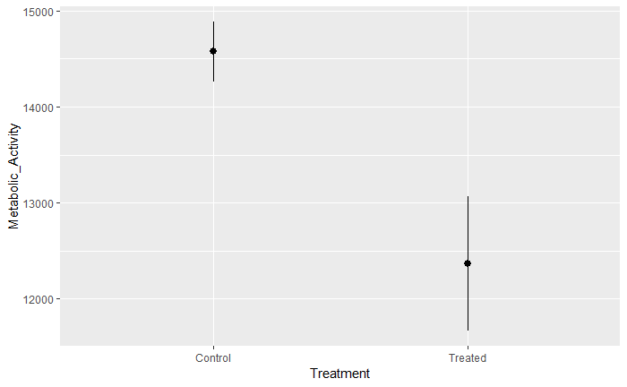

```r
cell_treatment_data %>%
  ggplot(aes(x=Treatment,y=Metabolic_Activity))+
  stat_summary()
```

Maybe we’d prefer a more familiar looking plot, with some different aesthetics, and some labels. Feel free to mess around with these!

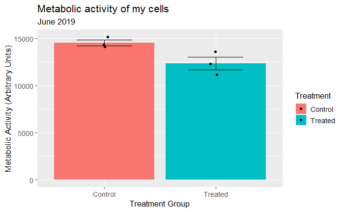

```r
cell_treatment_data %>%
  ggplot(aes(x=Treatment,y=Metabolic_Activity, fill=Treatment))+
  stat_summary(geom="bar")+
  stat_summary(geom="errorbar", width=0.5)+
  geom_jitter(width=0.1,height=0)+
  labs(title="Metabolic activity of my cells", subtitle="June 2019")+
  xlab("Treatment Group")+
  ylab("Metabolic Activity (Arbitrary Units)")+
  theme_gray(13)
```

You can save a plot like this:

```r
ggsave("ex1_plot.png")
```

# T-Test

Finally we’ll test the hypothesis that our groups have different means using a *T-Test*.

```r
cell_treatment_data %>%
  t.test(Metabolic_Activity~Treatment,data=.)
```

```
    Welch Two Sample t-test

data:  Metabolic_Activity by Treatment
t = 2.8885, df = 2.765, p-value = 0.06958
alternative hypothesis: true difference in means is not equal to 0
95 percent confidence interval:
 -345.5693 4756.9027
sample estimates:
mean in group Control mean in group Treated
             14574.00              12368.33
```

Generally, folks are interested in whether the p-value is below a significance threshold. However, R tells us some other potentially useful stuff, not least a 95% confidence bracket on the difference in means letting us say “We’re pretty sure the difference between the control and the treated groups is between x and y.”.

NB the proper definition of confidence interval is something to Google, if you want to!